# 185314135_Budi_K-Medoids

## K-Medoids Clustering

Clustering adalah seperangkat teknik yang luas untuk menemukan kelompok dalam kumpulan data.Tujuan utama analisis cluster adalah mengelompokkan objek-objek berdasarkan kesamaan karakteristik di antara objek-objek tersebut. Tahap-tahap pengerjaannya adalah sebagai berikut :

1. Replication Requirements
2. Data Preparation
3. Determining Optimal Clusters
4. K-Medoids Clustering
5. Clustering Distance Measures
6. Result Examination

### 1. Replication Requirements

Pada tahap ini kita mengimport library yang dibutuhkan.

```r
library(tidyverse)  # data manipulation
library(cluster)    # clustering algorithms
library(factoextra) # clustering algorithms & visualization
library (clValid)   # Evaluasi
```

### 2. Data Preparation

Hal yang perlu diperhatikan dalam data preparation untuk clustering adalah:

1. Data Format, baris adalah observation, nilai per individu, sedangkan kolom adalah nilai variabel
2. Replace/remove missing values, setiap nilai data yang hilang harus dihapus atau diisi.
3. Standarisasi data, terdiri dari transformasi variabel sehingga memiliki mean = 0 dan standar deviasi = 1.

Membaca data

```r
dataMedoid <- read.csv("contohsoal.csv",sep=",")
str(dataMedoid)
```

```
## 'data.frame':    8 obs. of  3 variables:
##  $ Lokasi: chr  "A1" "A2" "A3" "A4" ...
##  $ X     : int  2 2 8 5 7 6 1 4
##  $ Y     : int  10 5 4 8 5 4 2 9
```

```r
dataMedoid
```

```
##   Lokasi X  Y
## 1     A1 2 10
## 2     A2 2  5
## 3     A3 8  4
## 4     A4 5  8
## 5     A5 7  5
## 6     A6 6  4
## 7     A7 1  2
## 8     A8 4  9
```

Menghapus data yang missing atau hilang

```r
dataMedoid <- na.omit(dataMedoid)
```

Perbedaan K-Means dengan K-Medoids

Beberapa literatur ada yang menyatakan bahwa data outlier dapat dianalisis menggunakan K-Means, namun dengan batasan tertentu. Sehingga jika outlier melebihi batasan tersebut, maka lebih baik untuk menggunakan K-Medoids.

Outlier/Pencilan artinya suatu angka yang memiliki nilai yang sangat berbeda jauh dengan nilai dari angka lainya pada data,

Box plot biasanya digunakan untuk mendeteksi adanya Outlier/Pencilan atau tidak, tapi sifatnya hanya sebagai deteksi awal. Lebih bagus lagi jika dilakukan uji statistik untuk melihat ada atau tidaknya outlier.

```r
summary(is.na(dataMedoid[,2:3])) #melihat missing value
```

```
##      X               Y
##  Mode :logical   Mode :logical
##  FALSE:8         FALSE:8
```

```r
summary(dataMedoid[,2:3]) #melihat deskriptif data
```

```
##        X               Y
##  Min.   :1.000   Min.   : 2.000
##  1st Qu.:2.000   1st Qu.: 4.000
##  Median :4.500   Median : 5.000
##  Mean   :4.375   Mean   : 5.875
##  3rd Qu.:6.250   3rd Qu.: 8.250
##  Max.   :8.000   Max.   :10.000
```

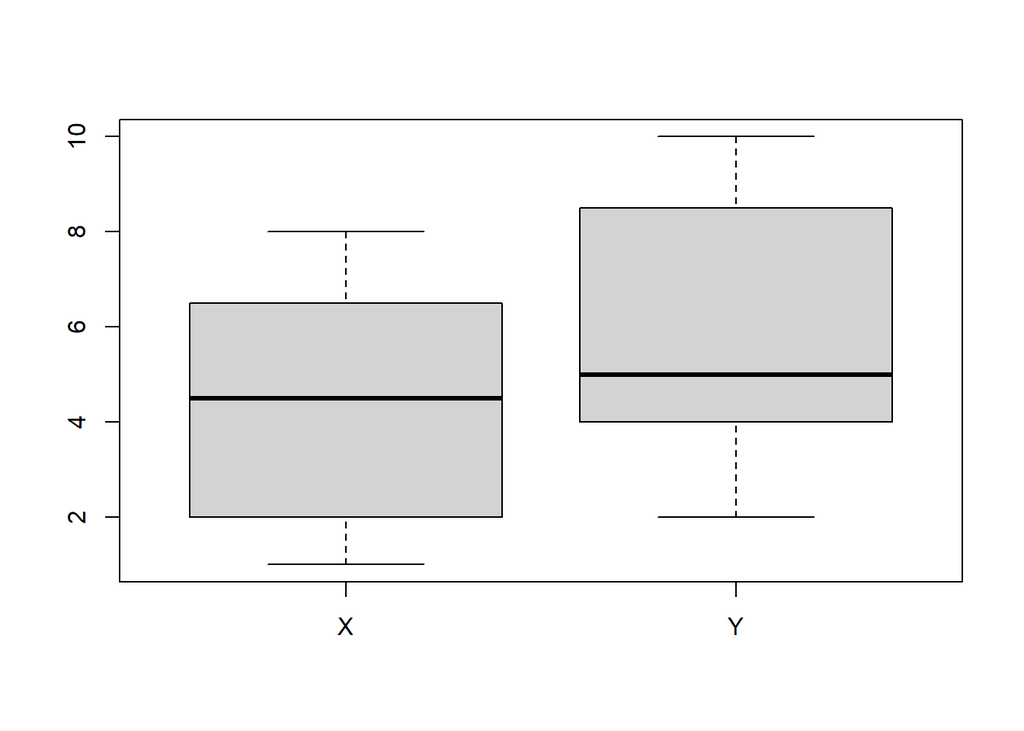

```r
boxplot(dataMedoid[,2:3]) #melihat data outlier
```

Menghilangkan kolom “Lokasi”

```r
dataMedoidX <- dataMedoid[-1]
dataMedoidX
```

```
##   X  Y
## 1 2 10
## 2 2  5
## 3 8  4
## 4 5  8
## 5 7  5
## 6 6  4
## 7 1  2
## 8 4  9
```

```r
str(dataMedoidX)
```

```
## 'data.frame':    8 obs. of  2 variables:
##  $ X: int  2 2 8 5 7 6 1 4
##  $ Y: int  10 5 4 8 5 4 2 9
```

Standarisasi data

```r
dataMedoidScale <- scale(dataMedoidX)
dataMedoidScale
```

```
##            X          Y
## 1 -0.9277364  1.4732814
## 2 -0.9277364 -0.3125142
## 3  1.4160187 -0.6696734
## 4  0.2441412  0.7589631
## 5  1.0253929 -0.3125142
## 6  0.6347670 -0.6696734
## 7 -1.3183622 -1.3839916
## 8 -0.1464847  1.1161223
## attr(,"scaled:center")
##     X     Y
## 4.375 5.875
## attr(,"scaled:scale")
##        X        Y
## 2.559994 2.799872
```

Uji Multikolinearitas

Jika nilai korelasi melebihi 0.5 maka hal itu menandakan bahwa terjadi multikolinearitas. Dari output matriks korelasi 2x2 pada hasil di bawah ini, terlihat bahwa nilai korelasi antar variabel berada di bawah 0.5 sehingga dapat disimpulkan bahwa asumsi tidak terjadi multikolinearitas telah terpenuhi. Sehingga, variabel-variabel tersebut dapat digunakan untuk analisis cluster.

```r
library(car)
multikolinearitas<-cor(dataMedoidX)
multikolinearitas
```

```
##            X          Y
## X  1.0000000 -0.1320415
## Y -0.1320415  1.0000000
```

### 3. Determining Optimal Clusters

Pada bagian ini akan dijelaskan tiga metode paling populer untuk menentukan cluster yang optimal, yaitu :

1. Silhouette Method
2. Elbow Method
3. Gap Statistic

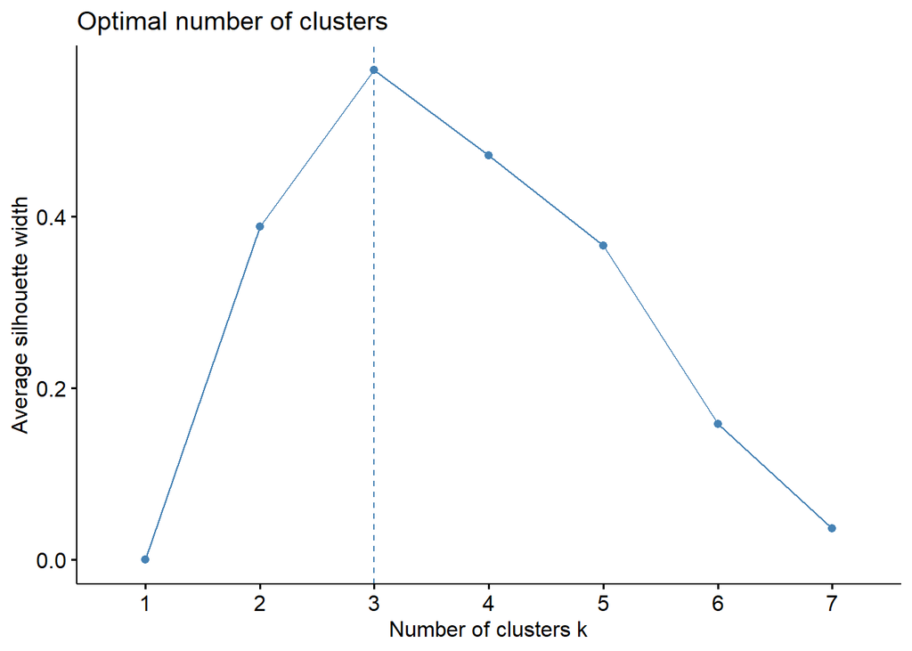

```r
fviz_nbclust(dataMedoidX, pam, method = "silhouette",k.max=7)
```

berdasarkan silhouette k terbaik yaitu 3 (dilihat dari titik tertinggi)

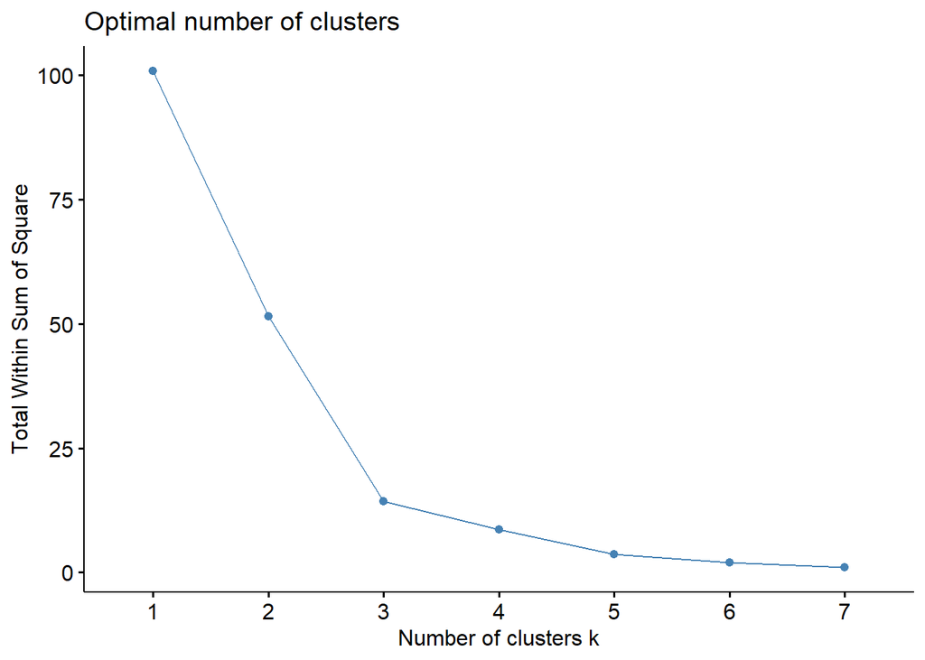

```r
set.seed(123)
fviz_nbclust(dataMedoidX,pam,method = "wss", k.max=7)
```

berdasarkan elbow k terbaik yaitu 3 (dilihat dari titik yang paling membentuk siku)

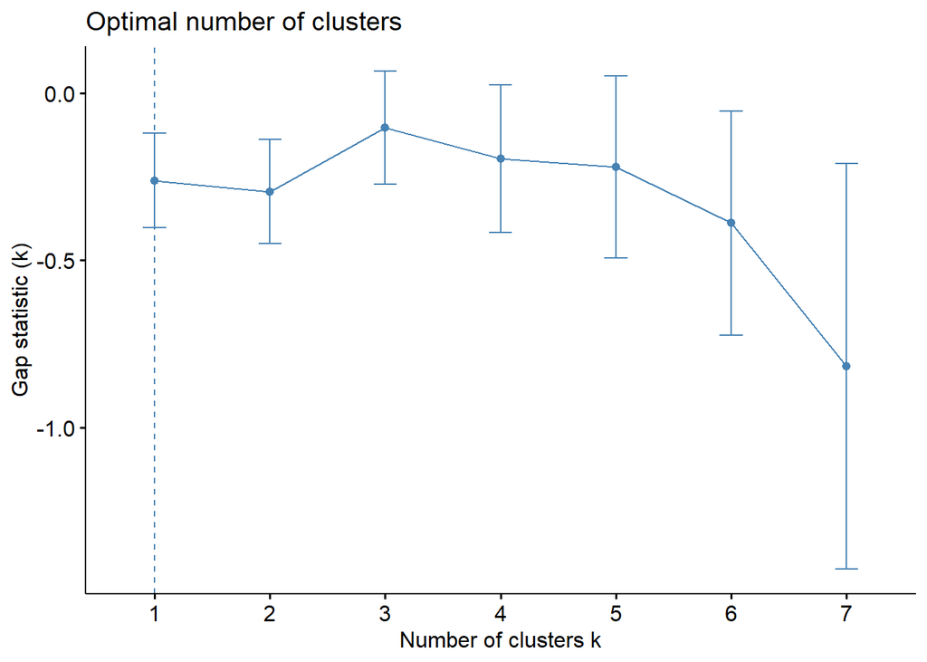

```r
gap_stat <- clusGap(dataMedoidX,
                    FUN = pam,
                    K.max = 7, #max clusters to consider
                    B = 30) #total bootstrapped iterations
fviz_gap_stat(gap_stat)
```

### 4. K-Medoids Clustering

Algoritma K-medoids adalah algoritma yang menemukan kelompok K-cluster(jumlah cluster) diantara semua objek data di dalam sebuah kelompok data. K-medoids tidak menentukan nilai rata-rata dari objek dalam cluster sebagai titik acuan, tapi menggunakan medoid(median), yang merupakan objek yang paling terletak di pusat sebuah cluster.

Langkah-langkah pengerjaan menggunakan K-Medoids:

1. Tetapkan jumlah K nya.
2. Menentukan medoid awal yang digunakan, pada kasus penggunaan R pada medoid awalnya nya telah ditentukan secara otomatis
3. Alokasikan setiap data (objek) ke cluster terdekat menggunakan persamaan ukuran jarak Euclidian Distance
4. Hitung jarak setiap objek yang berada pada masing-masing cluster dengan kandidat medoids baru.
5. Jumlahkan seluruh hasil perhitungan jarak terdekat berdasarkan medoids nya, kemudian cari total(SUM) paling terkecil.

```r
library(cluster)
pam.result <- pam(dataMedoidX,3)
print(pam.result)
```

```
## Medoids:
##   ID X Y
## 8  8 4 9
## 7  7 1 2
## 5  5 7 5
## Clustering vector:
## 1 2 3 4 5 6 7 8
## 1 2 3 1 3 3 2 1
## Objective function:
##    build     swap
## 1.449532 1.205123
##
## Available components:
##  [1] "medoids"    "id.med"     "clustering" "objective"  "isolation"
##  [6] "clusinfo"   "silinfo"    "diss"       "call"       "data"
```

dari hasil pengclusteran diatas didapat cluster 1 terdiri dari data 1, 4 dan 8 cluster 2 terdiri dari data 2 dan 7 cluster 3 terdiri dari data 3, 5 dan 6

Menghitung Jarak dengan menggunakan metric Euclidean Distance Ditampilkan dalam bentuk matriks

```r
pam.result$diss
```

```
## Dissimilarities :
##          1        2        3        4        5        6        7
## 2 5.000000
## 3 8.485281 6.082763
## 4 3.605551 4.242641 5.000000
## 5 7.071068 5.000000 1.414214 3.605551
## 6 7.211103 4.123106 2.000000 4.123106 1.414214
## 7 8.062258 3.162278 7.280110 7.211103 6.708204 5.385165
## 8 2.236068 4.472136 6.403124 1.414214 5.000000 5.385165 7.615773
##
## Metric :  euclidean
## Number of objects : 8
```

Hasil jarak yang divisualisasikan berdasarkan grafik gradien warna. semakin berwarna biru maka semakin mendekati 0 jaraknya, semakin berwarna merah maka semakin jauh jaraknya

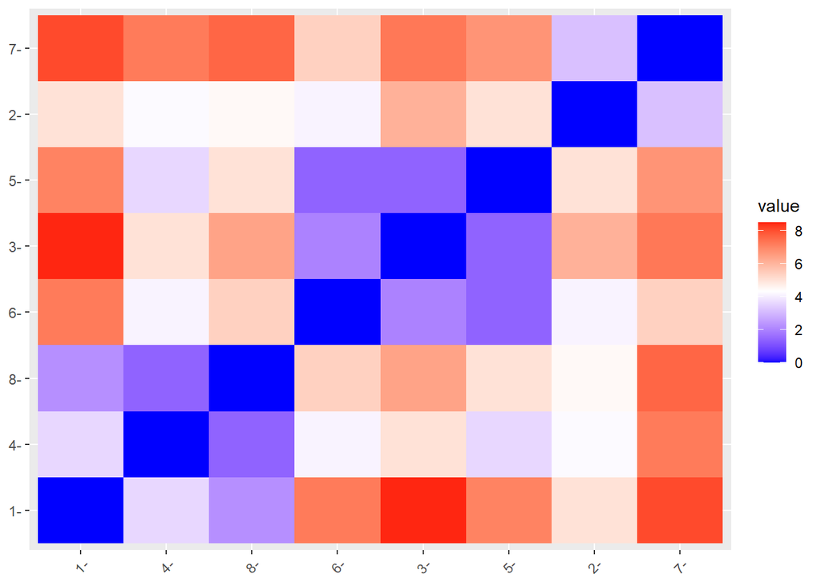

```r
distance <- get_dist(dataMedoidX)
fviz_dist(distance,gradient = list(low = "blue", mid = "white", high = "red"))
```

```r
show(distance)
```

```
##          1        2        3        4        5        6        7
## 2 5.000000
## 3 8.485281 6.082763
## 4 3.605551 4.242641 5.000000
## 5 7.071068 5.000000 1.414214 3.605551
## 6 7.211103 4.123106 2.000000 4.123106 1.414214
## 7 8.062258 3.162278 7.280110 7.211103 6.708204 5.385165
## 8 2.236068 4.472136 6.403124 1.414214 5.000000 5.385165 7.615773
```

Hasil final cluster dapat dilihat sebagai berikut ini:

```r
#add cluster assignment to original data
#final_data <- cbind(dataMedoid[,2:3], cluster = kmed$cluster)
kmed <- pam(dataMedoidX, 3)
final_data <- cbind(dataMedoidX, cluster = kmed$cluster)
final_data
```

```
##   X  Y cluster
## 1 2 10       1
## 2 2  5       2
## 3 8  4       3
## 4 5  8       1
## 5 7  5       3
## 6 6  4       3
## 7 1  2       2
## 8 4  9       1
```

hasil finalnya dapt kita lihat dengan k=3 cluster 1 terdiri dari data 1, 4 dan 8 cluster 2 terdiri dari data 2 dan 7 cluster 3 terdiri dari data 3, 5 dan 6

```r
#view final data
head(final_data)
```

```
##   X  Y cluster
## 1 2 10       1
## 2 2  5       2
## 3 8  4       3
## 4 5  8       1
## 5 7  5       3
## 6 6  4       3
```

```r
### dataframe hasil cluster ###
df.cluster = data.frame(dataMedoid,pam.result$cluster)
df.cluster
```

```
##   Lokasi X  Y pam.result.cluster
## 1     A1 2 10                  1
## 2     A2 2  5                  2
## 3     A3 8  4                  3
## 4     A4 5  8                  1
## 5     A5 7  5                  3
## 6     A6 6  4                  3
## 7     A7 1  2                  2
## 8     A8 4  9                  1
```

```r
table(pam.result$clustering, dataMedoid$Lokasi)
```

```
##
##     A1 A2 A3 A4 A5 A6 A7 A8
##   1  1  0  0  1  0  0  0  1
##   2  0  1  0  0  0  0  1  0
##   3  0  0  1  0  1  1  0  0
```

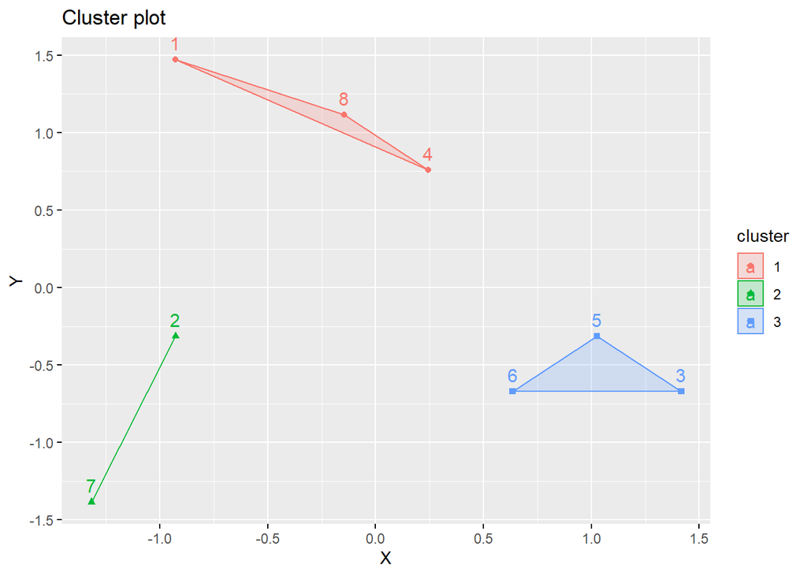

```r
## plot cluster
fviz_cluster(pam.result, data = dataMedoid[,2:3])
```

Menghitung rata-rata dari setiap cluster.

```r
dataMedoidX %>%
  mutate(Cluster = pam.result$cluster) %>%
  group_by(Cluster) %>%
  summarise_all("mean")
```

```
## # A tibble: 3 x 3
##   Cluster     X     Y
##     <int> <dbl> <dbl>
## 1       1  3.67  9
## 2       2  1.5   3.5
## 3       3  7     4.33
```

```r
sil <- silhouette(final_data$cluster,dist(distance))
head(sil[, 1:3], 8)
```

```
##      cluster neighbor sil_width
## [1,]       1        2 0.4407940
## [2,]       2        1 0.1806059
## [3,]       3        2 0.6740305
## [4,]       1        3 0.3962961
## [5,]       3        1 0.7240766
## [6,]       3        2 0.6481147
## [7,]       2        3 0.4024198
## [8,]       1        2 0.6172014
```

```
##   cluster size ave.sil.width
## 1       1    3          0.48
## 2       2    2          0.29
## 3       3    3          0.68
```

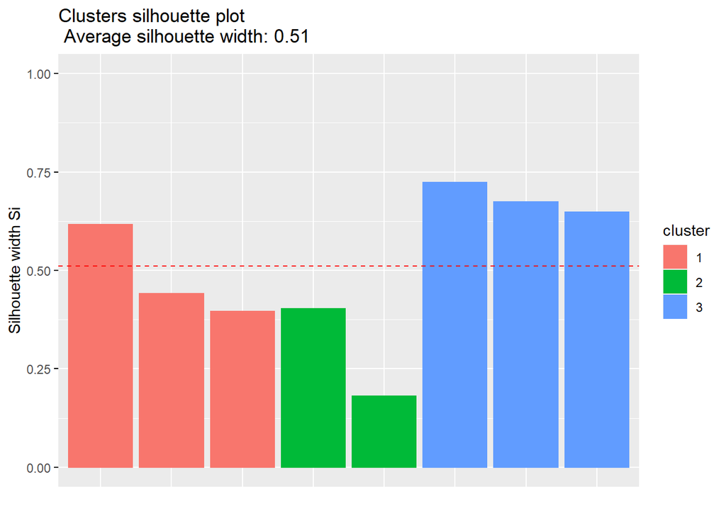

```r
fviz_silhouette(sil)
```

```r
si.sum <-summary(sil)
si.sum
```

```
## Silhouette of 8 units in 3 clusters from silhouette.default(x = final_data$cluster, dist = dist(distance)) :
##  Cluster sizes and average silhouette widths:
##         3         2         3
## 0.4847638 0.2915129 0.6820739
## Individual silhouette widths:
##    Min. 1st Qu.  Median    Mean 3rd Qu.    Max.
##  0.1806  0.4009  0.5290  0.5104  0.6546  0.7241
```

-Average proportion of non-overlap (APN) merupakan proporsi rata-rata data pada cluster berbeda dari dataset dan clustering berdasarkan dataset dengan menghilangkan satu kolom (variabel).

-Average Distance (AD) -> Rata-rata lintasan terpendek dari sebuah grafik, sesuai dengan jumlah semua lintasan terpendek antara pasangan simpul dibagi jumlah total pasangan simpul.

-Average distance between means (ADM) -> Mengukur jarak rata-rata antara pusat cluster untuk pengamatan yang ditempatkan di cluster yang sama di bawah kedua kasus

-Figure of merit (FOM) -> Mengukur varians intra-cluster rata-rata dari kolom yang dihapus, di mana pengelompokan didasarkan pada kolom yang tersisa (tidak dihapus).

```r
validate <- clValid(dataMedoidScale, nClust=2:7, clMethods = "pam", validation =
"stability", maxitems = 600, metric = "euclidean", method = "average",
neighbSize = 8, annotation = NULL, GOcategory = "all",
goTermFreq=0.05, dropEvidence=NULL, verbose=FALSE)
summary(validate)
```

```
##
## Clustering Methods:
##  pam
##
## Cluster sizes:
##  2 3 4 5 6 7
##
## Validation Measures:
##               2      3      4      5      6      7
##
## pam APN  0.2333 0.1458 0.2083 0.2083 0.1875 0.1250
##     AD   1.3013 0.8123 0.6586 0.4963 0.4009 0.2981
##     ADM  0.5572 0.4665 0.4683 0.3697 0.3539 0.2964
##     FOM  1.0502 0.9049 0.7576 0.8322 0.9812 1.3219
##
## Optimal Scores:
##
##     Score  Method Clusters
## APN 0.1250 pam    7
## AD  0.2981 pam    7
## ADM 0.2964 pam    7
## FOM 0.7576 pam    4
```

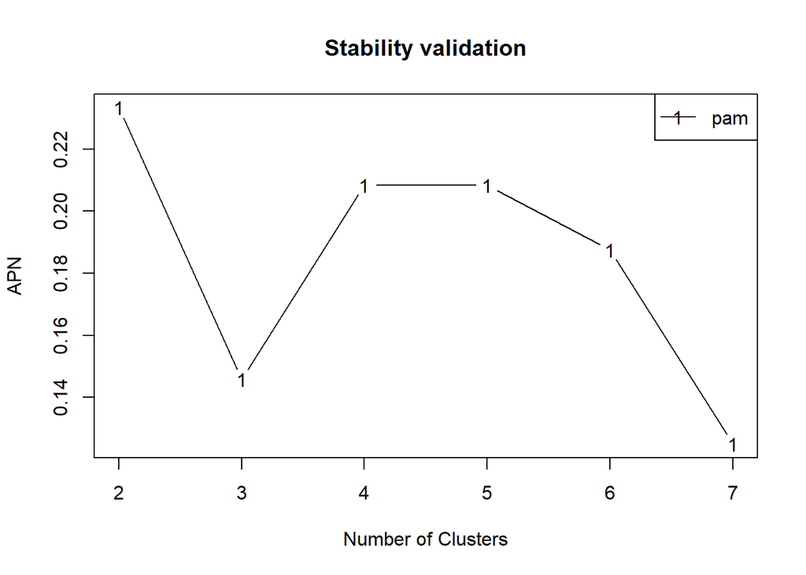

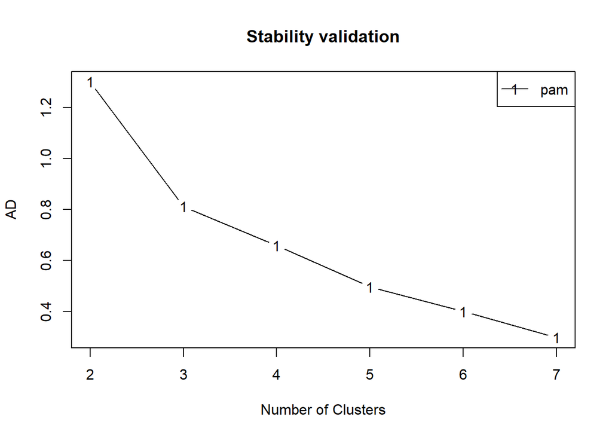

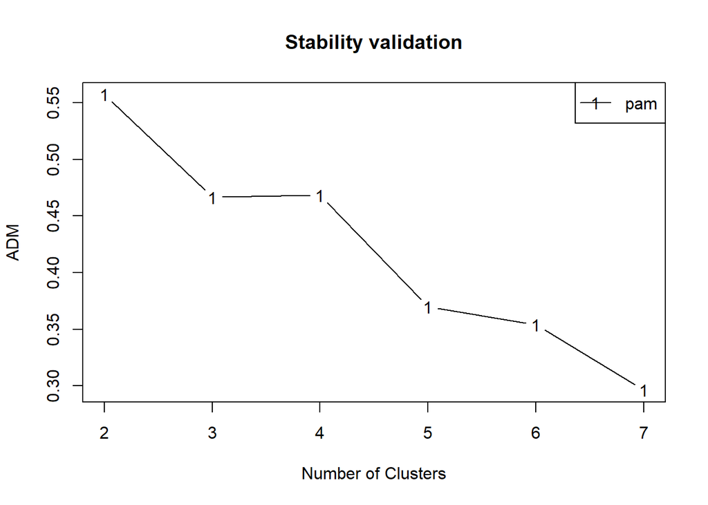

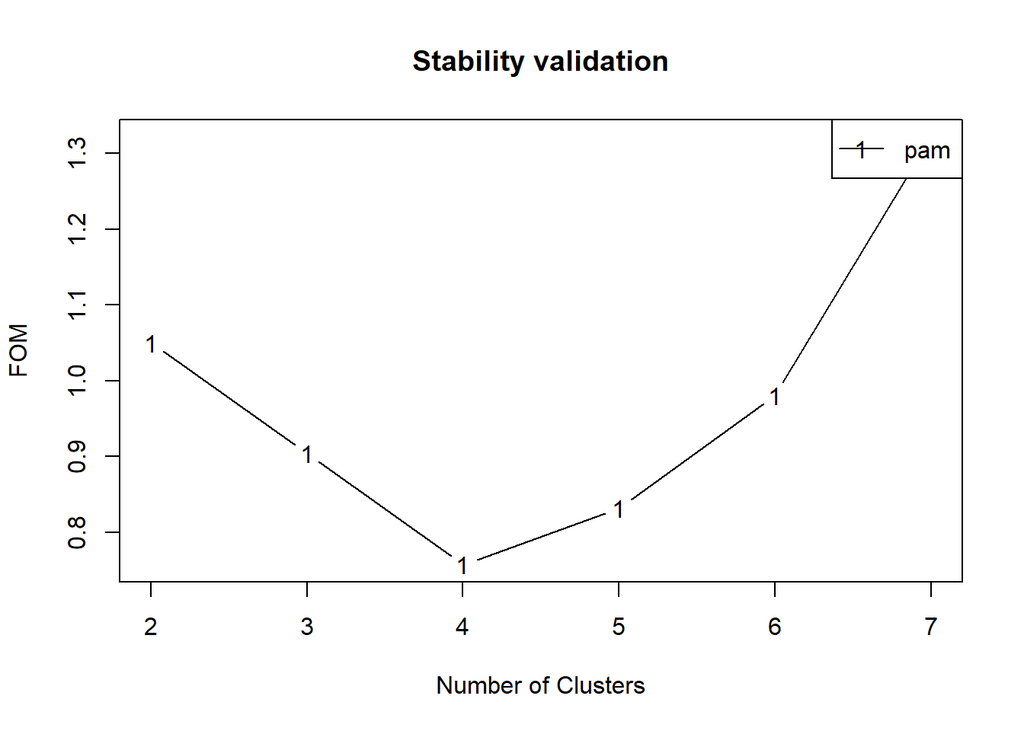

```r
plot(validate)
```